# support-vector-machines

## Support Vector Machines

**Support vector machines** (SVMs) bear some similarity to logistic regression. They learn a particular linear decision boundary called the **maximum margin hyperplane** (mmh). In a 2-class, linearly separable problem, the mmh is the hyperplane maximizing the distance to the closest points of each class (these points are called **support vectors**).

Only the support vectors are relevant to defining the hyperplane. The other points are not, and this indicates that SVMs are resilient to overfitting (adding a new point far from the support vectors doesn't affect the system).

[figure not shown]

In `scikit-learn`, the package `sklearn.svm` defines several SVM implementations for classification and regression.

```python
import matplotlib
import matplotlib.pyplot as plt
import numpy as np;
import pandas as pd
import sklearn.metrics as metrics

# Read in a data set using Pandas.
wdbc_data = '../data-sets/wdbc.csv'
df = pd.read_csv(wdbc_data, header=0)
print("shape:\t",df.shape)
df.head()
```

```
shape:	 (569, 32)
```

|  | id | radiusAvg | textureAvg | perimeterAvg | areaAvg | smoothnessAvg | compactnessAvg | concavityAvg | concavepointsAvg | symmetryAvg | ... | textureWorst | perimeterWorst | areaWorst | smoothnessWorst | compactnessWorst | concavityWorst | concavepointsWorst | symmetryWorst | fractaldimWorst | c |
| --- | --- | --- | --- | --- | --- | --- | --- | --- | --- | --- | --- | --- | --- | --- | --- | --- | --- | --- | --- | --- | --- |
| 0 | 842302 | 17.99 | 10.38 | 122.80 | 1001.0 | 0.11840 | 0.27760 | 0.3001 | 0.14710 | 0.2419 | ... | 17.33 | 184.60 | 2019.0 | 0.1622 | 0.6656 | 0.7119 | 0.2654 | 0.4601 | 0.11890 | 0 |
| 1 | 842517 | 20.57 | 17.77 | 132.90 | 1326.0 | 0.08474 | 0.07864 | 0.0869 | 0.07017 | 0.1812 | ... | 23.41 | 158.80 | 1956.0 | 0.1238 | 0.1866 | 0.2416 | 0.1860 | 0.2750 | 0.08902 | 0 |
| 2 | 84300903 | 19.69 | 21.25 | 130.00 | 1203.0 | 0.10960 | 0.15990 | 0.1974 | 0.12790 | 0.2069 | ... | 25.53 | 152.50 | 1709.0 | 0.1444 | 0.4245 | 0.4504 | 0.2430 | 0.3613 | 0.08758 | 0 |
| 3 | 84348301 | 11.42 | 20.38 | 77.58 | 386.1 | 0.14250 | 0.28390 | 0.2414 | 0.10520 | 0.2597 | ... | 26.50 | 98.87 | 567.7 | 0.2098 | 0.8663 | 0.6869 | 0.2575 | 0.6638 | 0.17300 | 0 |
| 4 | 84358402 | 20.29 | 14.34 | 135.10 | 1297.0 | 0.10030 | 0.13280 | 0.1980 | 0.10430 | 0.1809 | ... | 16.67 | 152.20 | 1575.0 | 0.1374 | 0.2050 | 0.4000 | 0.1625 | 0.2364 | 0.07678 | 0 |

5 rows × 32 columns

## Scaling the data

Below, we use a [`StandardScaler`](http://scikit-learn.org/stable/modules/generated/sklearn.preprocessing.StandardScaler.html), which transforms features to have mean 0 and standard deviation 1. Some estimators require that data be transformed in this way. With SVMs, it is generally the case that the data should be scaled.

```python
from sklearn.model_selection import train_test_split
#from  sklearn.preprocessing import MinMaxScaler
from sklearn.preprocessing import StandardScaler

data = df.iloc[:].values

test_percent = 0.3

# extract X and y values from the data set;
X = data[:, 1:-1]
y = data[:, -1]

sc = StandardScaler()
X = sc.fit_transform(X)

X_train, X_test, y_train, y_test =  train_test_split(X, y, test_size=test_percent, shuffle=True)

print("Training set size:", len(y_train))
print("Testing set size:", len(y_test))
print("Input attributes:",X.shape[1])
```

```
Training set size: 398
Testing set size: 171
Input attributes: 30
```

## Creating a Classifier

[`svm.SVC`](http://scikit-learn.org/stable/modules/generated/sklearn.svm.SVC.html#sklearn.svm.SVC), [`svm.NuSVC`](http://scikit-learn.org/stable/modules/generated/sklearn.svm.NuSVC.html#sklearn.svm.NuSVC) and [`svm.LinearSVC`](http://scikit-learn.org/stable/modules/generated/sklearn.svm.LinearSVC.html#sklearn.svm.LinearSVC) are classifier algorithms, the latter of these assuming a linear kernel.

Each is capable of performing multiclass classification. If there are $n$ distinct classes, `LinearSVC` generates $n$ distinct class models (one vs. rest). An exception to this is if there are only two classes; in that case, only one model is needed.

For `SVC` and `NuSVC`, a model is generated to distinguish pairs of classes (one vs one).

```python
from sklearn.svm import SVC, NuSVC, LinearSVC

clf1 = SVC()
clf2 = NuSVC()
linSVC = LinearSVC()

for clf in [clf1,clf2,linSVC]:
    clf.fit(X_train, y_train)
    predicted= np.array(clf.predict(X_test))
    cm = metrics.confusion_matrix(y_test, predicted,labels=[1,0])
    print(clf,"\n")
    print("","B","M",sep="\t")
    print("B",cm[0,0],cm[0,1],sep="\t" )
    print("M",cm[1,0],cm[1,1],sep="\t" )
    print()
    print('-'*20)
    print("accuracy:", metrics.accuracy_score(predicted,y_test))
```

```
SVC(C=1.0, break_ties=False, cache_size=200, class_weight=None, coef0=0.0,
    decision_function_shape='ovr', degree=3, gamma='scale', kernel='rbf',
    max_iter=-1, probability=False, random_state=None, shrinking=True,
    tol=0.001, verbose=False)

	B	M
B	108	0
M	2	61

--------------------
accuracy: 0.9883040935672515
NuSVC(break_ties=False, cache_size=200, class_weight=None, coef0=0.0,
      decision_function_shape='ovr', degree=3, gamma='scale', kernel='rbf',
      max_iter=-1, nu=0.5, probability=False, random_state=None, shrinking=True,
      tol=0.001, verbose=False)

	B	M
B	105	3
M	4	59

--------------------
accuracy: 0.9590643274853801
LinearSVC(C=1.0, class_weight=None, dual=True, fit_intercept=True,
          intercept_scaling=1, loss='squared_hinge', max_iter=1000,
          multi_class='ovr', penalty='l2', random_state=None, tol=0.0001,
          verbose=0)

	B	M
B	106	2
M	2	61

--------------------
accuracy: 0.9766081871345029
```

### `decision_function`

The method `decision_function` will output the signed distance for an instance to the hyperplane. Below, we manually calculate the accuracy of the `linearSVC` classifier by determining the sign of the distance.

```python
print("accuracy (built-in) \t{:.3f}".format( metrics.accuracy_score(clf.predict(X_test),y_test)))

predicted = linSVC.decision_function(X_test)

print("accuracy (manual) \t{:.3f}".format(np.count_nonzero(y_test == (predicted>0))/len(y_test)))

print("targets vs. predicted")
for actual, pred in zip(y_test, predicted):
    print("{:}\t{}\t{:.4f}".format(actual,pred>0,pred))
```

```
accuracy (built-in) 	0.977
accuracy (manual) 	0.977
targets vs. predicted
1.0	True	1.3646
0.0	False	-9.2585
1.0	True	4.1075
0.0	False	-6.5187
0.0	False	-6.3056
1.0	True	1.8033
1.0	True	2.5794
1.0	True	3.1858
1.0	True	3.4639
1.0	True	3.1889
1.0	True	1.7531
1.0	True	0.6328
0.0	False	-7.1144
1.0	True	2.0709
0.0	True	1.3740
1.0	True	3.3958
1.0	True	1.4430
0.0	False	-6.7450
0.0	False	-6.1951
1.0	True	3.2951
1.0	True	3.9516
1.0	True	2.3692
1.0	True	3.0338
1.0	True	0.9417
1.0	False	-0.2645
1.0	True	1.9096
1.0	True	3.6044
1.0	True	3.1619
1.0	False	-0.0646
1.0	True	3.3302
0.0	False	-8.1249
1.0	True	2.8770
1.0	True	1.1871
1.0	True	4.1547
0.0	False	-4.4003
1.0	True	4.2457
1.0	True	4.9792
```

[output cut: 119 more lines]

```
1.0	True	4.7693
1.0	True	2.1882
0.0	False	-1.2437
0.0	False	-2.0170
1.0	True	4.1618
0.0	False	-4.5735
0.0	False	-0.0683
0.0	False	-3.2110
1.0	True	3.3976
0.0	False	-6.6408
0.0	False	-2.4812
0.0	False	-11.2433
1.0	True	1.3784
1.0	True	3.5562
1.0	True	2.9400
```

The `wdbc` data set has only two classes. For data sets with more classes, `decision_function` will return a sequence of values for each instance. The values are confidence scores for each class.

The dimensions of the returned matrix will depend on which decision function type is used.

Below, we load the iris data set, which has 3 classes.

```python
from sklearn import datasets
iris = datasets.load_iris()
iris_x = iris.data
iris_y = iris.target
X_train, X_test, y_train, y_test =  train_test_split(iris_x, iris_y, test_size=test_percent, shuffle=True)

clf1 = SVC()
clf2 = NuSVC()
linSVC = LinearSVC()

for clf in [clf1,clf2,linSVC]:
    clf.fit(X_train, y_train)
    predicted= np.array(clf.predict(X_test))
    cm = metrics.confusion_matrix(y_test, predicted,labels=[0,1,2])
    print("\t0\t1\t2\t")
    print("\t-\t-\t-\t")
    print("0|",cm[0,0],cm[0,1],cm[0,2],sep="\t" )
    print("1|",cm[1,0],cm[1,1],cm[1,2],sep="\t" )
    print("2|",cm[2,0],cm[2,1],cm[2,2],sep="\t" )
    print("accuracy:", metrics.accuracy_score(predicted,y_test))
    print('-'*20)
print('-'*80)
predicted = linSVC.decision_function(X_test)
count = 0
for i in range(len(y_test)):
    print(y_test[i], predicted[i], np.argmax(predicted[i]))
    if y_test[i] == np.argmax(predicted[i]):
        count = count+1
print(count/len(y_test))
```

```
	0	1	2
	-	-	-
0|	15	0	0
1|	0	13	1
2|	0	0	16
accuracy: 0.9777777777777777
--------------------
	0	1	2
	-	-	-
0|	15	0	0
1|	0	13	1
2|	0	0	16
accuracy: 0.9777777777777777
--------------------
	0	1	2
	-	-	-
0|	15	0	0
1|	0	13	1
2|	0	2	14
accuracy: 0.9333333333333333
--------------------
--------------------------------------------------------------------------------
2 [-2.50813363  0.71411302  0.93840696] 2
0 [ 1.14472686 -0.39527731 -6.42637802] 0
1 [-1.82210075 -0.04002888 -0.70911523] 1
2 [-2.91889894 -0.14670349  1.83169131] 2
1 [-1.79855038  0.21679599 -0.6040758 ] 1
0 [ 1.04844113 -0.97870747 -6.51422275] 0
0 [ 1.17137495 -0.26718795 -6.53898323] 0
0 [ 1.42448798 -0.97211396 -7.05610577] 0
0 [ 1.79674233 -1.39003185 -8.3526893 ] 0
2 [-3.01689036 -0.31220295  1.96542791] 2
2 [-2.74891459  0.86583956  0.97885943] 2
1 [-2.23670008  0.39125826  0.20860804] 1
1 [-1.85371769 -0.14532532 -0.23714051] 1
2 [-2.61749767  0.32665854  0.28711369] 1
0 [ 1.053785   -0.38405745 -6.18442394] 0
1 [-2.0673139   0.39814472  0.12151351] 1
0 [ 1.24639798 -0.93381216 -6.78787391] 0
1 [-1.49972129 -0.02939494 -1.37673812] 1
```

[output cut: 13 more lines]

```
1 [-1.66841146  0.10831619 -1.28767523] 1
2 [-2.58616645 -0.87217817  1.32573508] 2
2 [-2.65339248 -0.08026015  1.75258505] 2
1 [-1.58521517 -0.22422059 -1.63981513] 1
2 [-2.38158269 -0.19432129  0.74157765] 2
2 [-2.86347443 -0.76469773  1.8036233 ] 2
0 [ 1.46053588 -0.74461528 -7.34787995] 0
1 [-1.83283002  0.48728611 -0.58957341] 1
1 [-1.36018378  0.3701839  -1.26912972] 1
2 [-2.71880872 -0.50696836  1.12302379] 2
1 [-1.759199   -0.46853328 -0.84240079] 1
0 [ 1.4338878  -0.87270464 -7.23527474] 0
1 [-2.40838509  0.26565868  0.65086248] 2
2 [-3.1383131   0.45438189  1.37404931] 2
0.9333333333333333
```

## Visualization

The below code (from Python Machine Learning, 2e, by Sebastian Raschka) defines a function which will graphically display both data points as well as decision boundaries between classes.

```python
from matplotlib.colors import ListedColormap
import matplotlib.pyplot as plt


def plot_decision_regions(X, y, classifier, test_idx=None, resolution=0.02):

    # setup marker generator and color map
    markers = ('s', 'x', 'o', '^', 'v')
    colors = ('red', 'blue', 'lightgreen', 'gray', 'cyan')
    cmap = ListedColormap(colors[:len(np.unique(y))])

    # plot the decision surface
    x1_min, x1_max = X[:, 0].min() - 1, X[:, 0].max() + 1
    x2_min, x2_max = X[:, 1].min() - 1, X[:, 1].max() + 1
    xx1, xx2 = np.meshgrid(np.arange(x1_min, x1_max, resolution),
                           np.arange(x2_min, x2_max, resolution))
    Z = classifier.predict(np.array([xx1.ravel(), xx2.ravel()]).T)
    Z = Z.reshape(xx1.shape)
    plt.contourf(xx1, xx2, Z, alpha=0.3, cmap=cmap)
    plt.xlim(xx1.min(), xx1.max())
    plt.ylim(xx2.min(), xx2.max())

    for idx, cl in enumerate(np.unique(y)):
        plt.scatter(x=X[y == cl, 0],
                    y=X[y == cl, 1],
                    alpha=0.8,
                    c=colors[idx],
                    marker=markers[idx],
                    label=cl,
                    edgecolor='black')

    # highlight test samples
    if test_idx:
        # plot all samples
        X_test, y_test = X[test_idx, :], y[test_idx]

        plt.scatter(X_test[:, 0],
                    X_test[:, 1],
                    c='',
                    edgecolor='black',
                    alpha=1.0,
                    linewidth=1,
                    marker='o',
                    s=100,
                    label='test set')
```

### Plotting Iris data

Below, we plot the boundaries for the iris data. We generate several plots, each indicating models trained on only two input features.

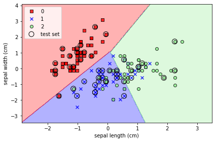

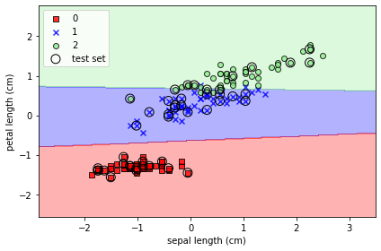

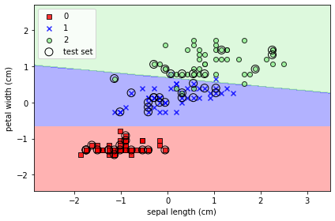

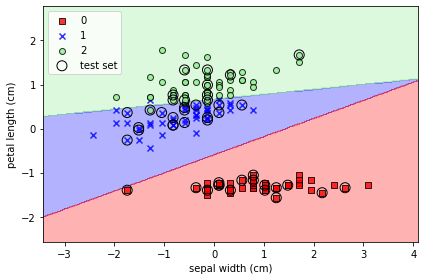

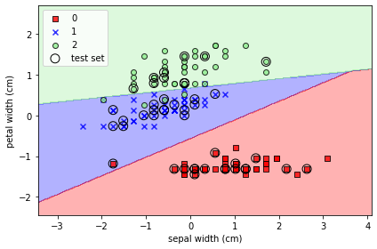

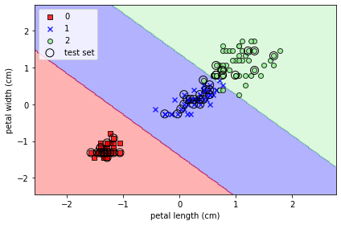

```python
features = iris.feature_names

X = iris.data[:]
y = iris.target
# scale the data
sc = StandardScaler()
X = sc.fit_transform(X)

X_train, X_test, y_train, y_test =  train_test_split(X, y, test_size=test_percent, shuffle=True)


for i in range(len(features)):
    for j in range(len(features)):
        if j <= i:
            continue
        X_train_2d = X_train[:,[i,j]]
        X_test_2d= X_test[:,[i,j]]
        X_combined = np.vstack((X_train_2d, X_test_2d))
        y_combined = np.hstack((y_train, y_test))
        # C is a penalty term used in SVC.
        # C "trades off misclassification of training examples against simplicity of the decision surface."
        svm = SVC(kernel='linear', C=1.0, random_state=1)
        svm.fit(X_train_2d, y_train)
        test_start = len(y_combined) - len(y_test)
        test_end = len(y_combined)
        plot_decision_regions(X_combined,
                      y_combined,
                      classifier=svm,
                      test_idx=range(test_start, test_end))
        plt.xlabel(features[i])
        plt.ylabel(features[j])
        plt.legend(loc='upper left')
        plt.tight_layout()
        plt.show()
```

### Using SVMs with non-linear problems

It is possible to develop classifiers for data sets that are not linearly separable. In these cases, a different "kernel" is used.

For `SVM` the possible values for `kernel` are:

- `linear`
- `poly` (polynomial)
- `rbf`: (radial basis function)
- `sigmoid`

For some, other parameters must be specified (e.g., `gamma`).

Below is a scatter plot of data that generates random points based on the XOR function (which is not linearly separable).

[The code is taken from **Python Machine Learning, 2e**].

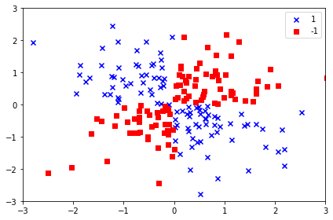

```python
import matplotlib.pyplot as plt
import numpy as np

np.random.seed(1)
X_xor = np.random.randn(200, 2)
y_xor = np.logical_xor(X_xor[:, 0] > 0,
                       X_xor[:, 1] > 0)
y_xor = np.where(y_xor, 1, -1)

plt.scatter(X_xor[y_xor == 1, 0],
            X_xor[y_xor == 1, 1],
            c='b', marker='x',
            label='1')
plt.scatter(X_xor[y_xor == -1, 0],
            X_xor[y_xor == -1, 1],
            c='r',
            marker='s',
            label='-1')

plt.xlim([-3, 3])
plt.ylim([-3, 3])
plt.legend(loc='best')
plt.tight_layout()
plt.show()
```

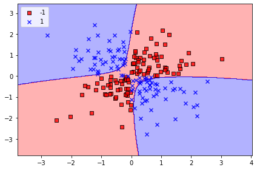

```python
svm = SVC(kernel='rbf', random_state=1, gamma=0.10, C=10.0)
svm.fit(X_xor, y_xor)
plot_decision_regions(X_xor, y_xor,classifier=svm)

plt.legend(loc='upper left')
plt.tight_layout()
plt.show()
```

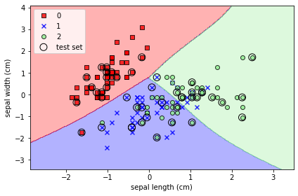

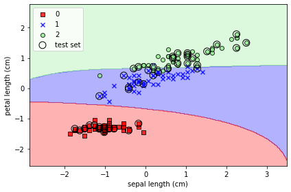

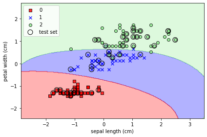

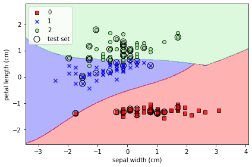

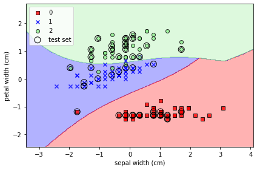

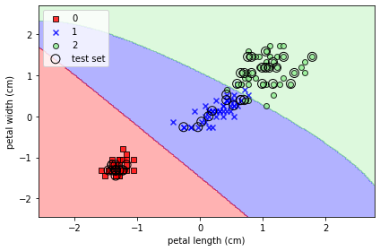

```python
import copy
features = iris.feature_names

X = iris.data
y = iris.target

sc = StandardScaler()
X = sc.fit_transform(X)

X_train, X_test, y_train, y_test =  train_test_split(X, y, test_size=test_percent, shuffle=True)


for i in range(len(features)):
    for j in range(len(features)):
        if j <= i:
            continue
        X_train_2d = X_train[:,[i,j]]
        X_test_2d= X_test[:,[i,j]]
        X_combined = np.vstack((X_train_2d, X_test_2d))
        y_combined = np.hstack((y_train, y_test))
        svm = SVC(kernel='rbf', random_state=1, gamma=0.2, C=1.0)
        svm.fit(X_train_2d, y_train)
        test_start = len(y_combined) - len(y_test)
        test_end = len(y_combined)
        plot_decision_regions(X_combined,
                      y_combined,
                      classifier=svm,
                      test_idx=range(test_start, test_end))
        plt.xlabel(features[i])
        plt.ylabel(features[j])
        plt.legend(loc='upper left')
        plt.tight_layout()
        plt.show()
```

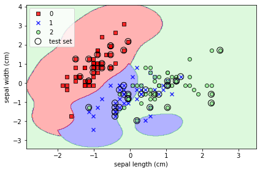

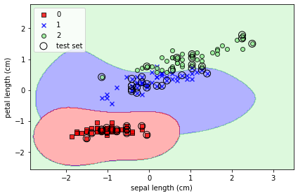

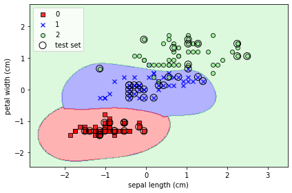

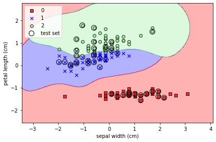

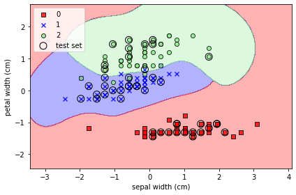

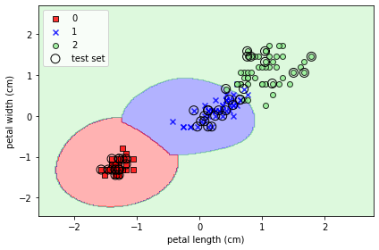

```python
features = iris.feature_names

X = iris.data[:]
y = iris.target

sc = StandardScaler()
X = sc.fit_transform(X)

X_train, X_test, y_train, y_test =  train_test_split(X, y, test_size=test_percent, shuffle=True)


for i in range(len(features)):
    for j in range(len(features)):
        if j <= i:
            continue
        X_train_2d = X_train[:,[i,j]]
        X_test_2d= X_test[:,[i,j]]
        X_combined = np.vstack((X_train_2d, X_test_2d))
        y_combined = np.hstack((y_train, y_test))
        svm = SVC(kernel='rbf', random_state=1, gamma=2, C=1.0)
        svm.fit(X_train_2d, y_train)
        test_start = len(y_combined) - len(y_test)
        test_end = len(y_combined)
        plot_decision_regions(X_combined,
                      y_combined,
                      classifier=svm,
                      test_idx=range(test_start, test_end))
        plt.xlabel(features[i])
        plt.ylabel(features[j])
        plt.legend(loc='upper left')
        plt.tight_layout()
        plt.show()
```